# TP1 Statistiques descriptives - rappels de R base

### **OBJECTIFS DU TP:**

- Le but de ce TP est de faire une piqûre de rappel sur ce qui a été vu en introduction à R, notamment sur la manipulation de bases de données. Ce TP se fera donc sans package.

**Rappels des séances précedentes (R base)** :

- Pour accéder à un élément (ou sélection) d’un vecteur ou d’une liste, on utilise les [ ]. Par exemple :

```r
mon_vecteur<-c(1,5,8,2)
# accéder au 2e élement :
mon_vecteur[2]
# On peut aussi utiliser un vecteur de la valeurs logiques, dès lors qu'il contient autant d'éléments que l'objet sur lequel on travaille.
mon_vecteur[c(FALSE,TRUE,FALSE,FALSE)]
```

- Dans le cas d’un objet de type data.frame (ou matrice), les crochets [ , ] permettent de faire une selection sur les lignes ou les colonnes :

```r
# Pour faire une sélection uniquement sur les lignes (avant la virgule des crochets):
mon_dataframe<-mon_dataframe[selection_lignes,]
# Dans l'exemple, selection_lignes est soit :
      # un vecteur de type numérique (index des lignes à conserver)
      # un vecteur de valeurs logiques (TRUE,FALSE) avec autant d'éléments dans ce vecteur qu'il y a de lignes dans le dataframe.

# Pour faire une sélection uniquement sur les colonnes (après la virgule des crochets)
mon_dataframe<-mon_dataframe[,selection_colonnes]
# Dans l'exemple, selection_colonnes est soit :
      # un vecteur de type numérique (index des colonnes à conserver)
      # un vecteur de valeurs logiques (TRUE,FALSE) avec autant d'éléments dans ce vecteur qu'il y a de colonnes dans le dataframe.
      # un vecteur de type character avec le nom des colonnes que l'on souhaite conserver : c("nom_variable1","nom_variable3")

# Pour faire une sélection sur lignes et colonnes
mon_dataframe<-mon_dataframe[selection_lignes,selection_colonnes]
```

- Pour afficher un descriptif du contenu d’une liste, on utilise la fonction `str()`. Un dataframe étant une liste de vecteurs nommés, on aura donc un descriptif de notre tableau de données de la manière suivante

```r
str(mon_dataframe)
```

- Pour accéder à (mais aussi pour créer) un élément nommé d’une liste, on utilise `$`. Un dataframe étant une liste de vecteurs nommés, on accéde à une variable de la façon suivante :

```r
mon_dataframe$ma_variable
```

- R est un langage vectoriel : dès lors qu’on applique une opération à un vecteur, elle s’applique à tous les éléments qui le composent :

```r
# Conversion d'une variable en character (tous les éléments sont convertis en character)
mon_dataframe$ma_variable<-as.character(mon_dataframe$ma_variable)
```

- Commencer par créer un répertoire TP1 pour y mettre les données du TP et vos futurs scripts.
- Pour rappel : chaque script commence par la commande rm(list=ls()) afin de vider l’environnement.

### Exercice 1 (Rappels des sessions précédentes : on fait du R base !)

Pour cet exercice nous allons utiliser plusieurs tables

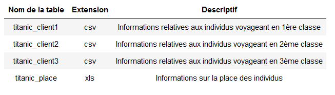

Le dictionnaire des variables des tables “titanic_clientN” est le suivant :

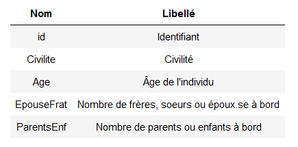

Le dictionnaire des variables de la table “titanic_place” est le suivant :

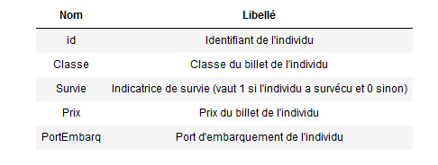

*Import et nettoyage de table*

1. Nous allons commencer par travailler sur la table “titanic_place”. Importer la table “titanic_place”, vous utiliserez la fonction `read_excel()` du package `` readxl``. Pour pouvoir utiliser un package, il faut au préalable le charger avec la commande ``library(mon_package)`. Si ce package n'est pas installé, l'installation se fait avec la commande suivante`install.packages(“mon_package”)`.

```r
# Début du programme
library(readxl)
titanic_place<-
```

2. Faites ensuite un résumé du contenu de la table. Les variables vous semblent-elles au bon format ?
3. Convertir la variable Classe en character. Convertir la variable Prix en numerique.
4. Y a t’il des doublons dans nos observations (plusieurs fois le même identifiant)? Rappel : utiliser la fonction `duplicated()`

*Quelques stats sur la variable quantitative : prix du billet*

5. Afficher la ligne du passager ayant payé son billet le plus cher. Pour cela, trier la table par ordre de prix décroissant et afficher la 1ere observation.
6. Afficher les passagers ayant payé les billets les moins chers. Vous utiliserez les fonctions `which()` et `min()`. Rappel : la fonction `which()` renvoie les numéros de lignes respectant une condition.
7. Faire un résumé statistique de la variable Prix. Faire également un boxplot de cette variable.

*Un peu de variables qualitatives : la classe et les survivants*

Les fonctions `table()` (respectivement `prop.table()`) permettent d’afficher les effectifs (resp. les pourcentages) d’une variable qualitative selon ses modalités.

8. Combien y a t’il de passagers dans chaque classe ?
9. Quels pourcentages de passagers appartiennent à chacune des classes ?
10. Le but de cette question est de déterminer combien il y a de survivants dans chaque classe. Cela revient à faire la somme des survivants en fonction de la variable qualitative classe (=group by en SQL). Les opérations de type group by se font de plusieurs manières. En R base, on privilégiera l’usage de la fonction `aggregate()`. Parfois certains utilisent sinon la fonction `tapply()`. Ces 2 fonctions sont substituables sur le principe mais ne renvoient pas le même type d’objet : aggregate renvoie un dataframe, tapply renvoie un array (rarement besoin).

10.a) Faire la question en utilisant la fonction `aggregate()` 10.b) Faire la question avec la fonction `tapply()`. La fonction `tapply()` fait partie de la famille des fonctions `apply()`. Cette famille de fonctions permet d’éviter de faire des boucles. En R, les boucles peuvent être très chronophages. La fonction tapply s’applique pour les opérations/boucles de type group by.

*UN PEU DE NOUVEAUTE*

11. On souhaite créer un projet R.

Rappel : un projet est un dossier qui centralise tous les fichiers nécessaires à notre travail (données, programme, énoncé, etc…). L’intérêt est de retrouver son environnement (et donc son travail) tel qu’on l’a laissé même si R a été fermé depuis. Un projet peut aussi être partagé. De sorte que quelqu’un qui récupère votre projet, récupère également votre environnement mais également vos chemins vers les fichiers.

Pour créer un projet R, 2 solutions :

- Créer un projet au moment où l’on commence notre travail
- Créer un projet plus tard (après que le travail ait commencé). C’est notre cas ici.

  11.a) Créer le projet R en faisant “File->New Project -> Existing Directory” et sélectionner votre répertoire de travail actuel (TP1). Et voilà!

  11.b) Sauvegarder votre programme et fermer R.

  11.c) Rouvrez R. Normalement, R s’ouvre là où vous l’avez laissé. Votre projet est relié à un dossier. En ouvrant un projet, le dossier auquel il est relié devient le répertoire de travail par défaut. Qu’est-ce que ça implique : Si vous voulez importer des données qui sont dans votre projet/dossier, vous n’avez pas besoin de préciser le chemin. Illustration avec la question suivante !

**PARENTHESE IMPORTANTE** : Par défaut, R s’ouvre sur le projet sur lequel on travaillait précédemment. Lors de votre prochaine session (pour le cours d’analyse factorielle par exemple), R s’ouvrira donc sur le projet TP1. Vous pourrez fermer votre projet TP1 en cliquant sur “Close project” dans la liste déroulante tout en haut à droite (en dessous de la croix pour fermer R).

11.d) Nous allons maintenant travailler sur les autres tables. Importer ces tables sans préciser autre chose que le séparateur (utilisez uniquement `sep=","` comme option dans votre fonction d’import). Pas besoin de préciser le chemin si l’on a bien fait notre projet!

*Rajout de données : concaténation*

12. Concaténer ces tables pour créer la table “titanic_client”. Au préalable, assurez-vous que les variables sont de même type pour pouvoir être concaténées.

*PARENTHESE SUR LES FACTORS*

13. Le but des questions 13 à 16 est de sensibiliser au fait que l’on ne peut pas convertir une variable de type factor en numérique juste en utilisant as.numeric(). Illustration avec la variable de prix du billet:

A partir du fichier titanic_place.xlsx, créer une table “id14_15_16” contenant les individus associés aux identifiants “id14”, id15” et “id16” en lançant la commande suivante:

```r
# Import du fichier titanic_place du début de TP
question13<-readxl::read_excel("titanic_place.xlsx")
question13$Prix<-as.factor(question13$Prix)
# La syntaxe package::fonction() permet de ne pas avoir à charger le package au préalable.
# Elle permet également de s'assurer qu'un package spécifique est utilisé.
# En effet, il est fréquent d'avoir des mêmes noms de fonctions issus de packages différents.
# avec l'option stringsAsFactors=TRUE, les variables de type char sont stockées par défaut au format factor.

id14_15_16<-question13[question13$id %in% c("id14","id15","id16"),]
```

Quel est le prix du billet payé par nos trois individus ?

14. Au sein de la table “id14_15_16”, convertir la variable Prix en numérique en lançant le code suivant : `id14_15_16$Prix <- as.numeric(id14_15_16$Prix)`. Quel est maintenant le prix payé par nos individus ? Pourquoi ?
15. Avec la fonction `remove()` ou `rm()`, supprimer la table “id14_15_16” de l’environnement”.
16. Reprenons la table “question13”, convertir correctement la variable Prix en numérique. Vous pourrez utiliser pour cela la syntaxe `as.numeric(as.character())`.

*Rajout de données : fusion puis nettoyage !*

17. Reprenons la table “titanic_client”, y a-t-il des doublons ? Si oui, les enlever. Convertir également la variable Age en numérique.
18. Fusionner les tables titanic_client et titanic_place pour créer la table “titanic_passager”.
19. Combien y a-t-il de valeurs manquantes pour la variable Age ? Créer la table “titanic_svm” qui contiendra uniquement les observations pour lesquelles l’âge est renseigné.
20. La suite de l’exercice se fera sur la table titanic_svm. Créer une variable Sexe qui comportera 2 modalités “Homme” et “Femme”. Pour construire notre variable, on s’appuiera sur la description suivante.

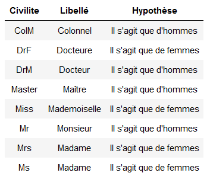

*Dernières stats : un mix*

21. Calculer l’âge moyen des passagers puis l’âge moyen par sexe.
22. Faire un boxplot croisant la variable de prix du billet selon la Classe.
23. Donnez le nombre de survivants hommes selon la classe d’embarquement.
24. Créer une variable Sexe_modif qui équivaut à la variable Sexe, à la différence que si l’âge est inférieur ou égal à 12, sexe_modif vaudra “Enfant”
25. Quelle est la proportion d’hommes, de femmes et d’enfants sur le bâteau ?
26. Quelle est la proportion d’hommes, de femmes et d’enfants parmi les survivants?
27. Calculer le taux de survie selon la variable Sexe_modif (taux de survie chez les hommes, chez les femmes et chez les enfants). D’après vous, est-ce que l’impératif “les femmes et les enfants d’abord” a été respecté ?
28. Croiser maintenant la porte d’embarquement et la classe.
29. Combien y a t’il eu d’hommes survivants selon la classe et la porte d’embarquement ?